[figure not shown]

# PTM Enrichment: PTM-SEA, Kinase GSEA, and MEA

**Overview**

This **DPA** report compares three enrichment methods from validated JSON stored in the final MuData.

[figure not shown]

**PTM-SEA** tests curated PTM signatures, **Kinase GSEA** tests predicted kinase substrate sets, and **MEA** shows native motif enrichment from the kinase-library workflow. Rendering does not rerun enrichment.

Table 1: Stored enrichment documents and result counts for this PTM analysis.

| Analysis | Method | Contrasts | Terms | FDR-significant |
| --- | --- | --- | --- | --- |
| DPA | PTM-SEA | 2 | 12 | 10 |
| DPA | Kinase GSEA | 2 | 12 | 10 |
| DPA | MEA | 2 | 12 | 10 |

**PTM-SEA**

**Summary**

Table 2: DPA PTM-SEA: result counts by contrast and direction.

| Contrast | Tested terms | FDR-significant | Positive NES | Negative NES |
| --- | --- | --- | --- | --- |
| a vs b | 6 | 4 | 3 | 1 |
| c vs b | 6 | 6 | 3 | 3 |

**Dot plot**

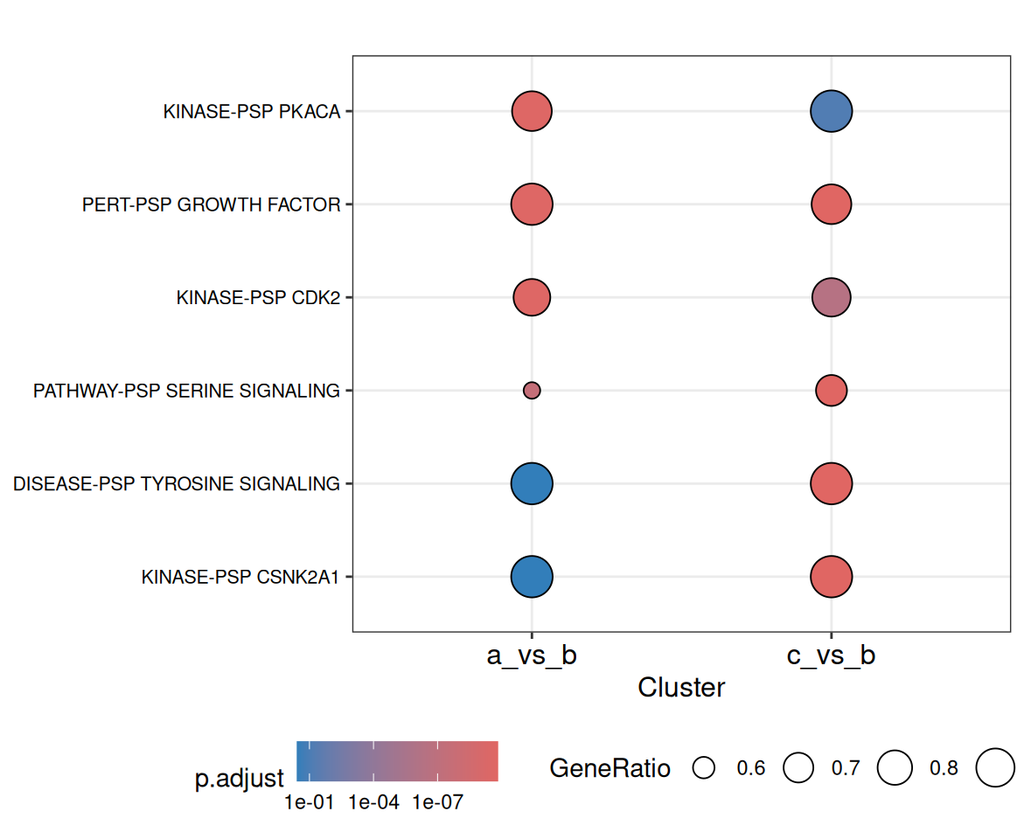

Figure 1: DPA PTM-SEA: leading enrichment terms reconstructed from JSON.

**Heatmap**

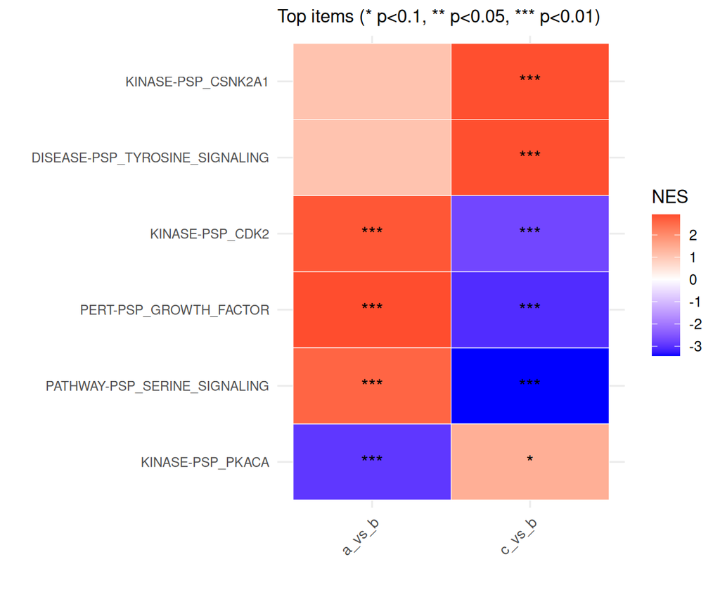

Figure 2: DPA PTM-SEA: normalized enrichment scores across contrasts.

**Volcano**

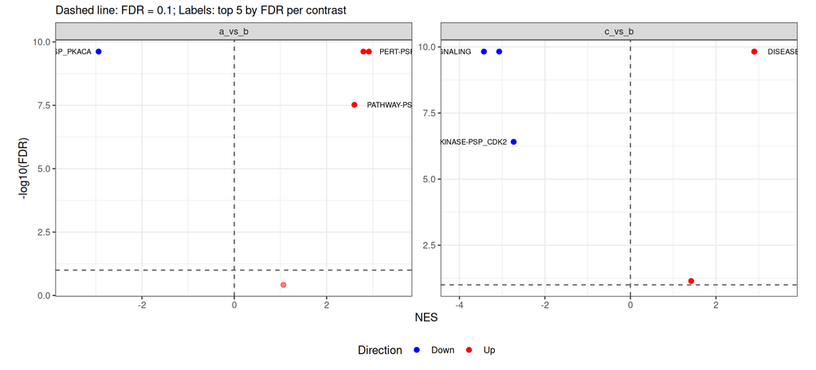

Figure 3: DPA PTM-SEA: normalized enrichment score versus FDR.

**Rank distributions**

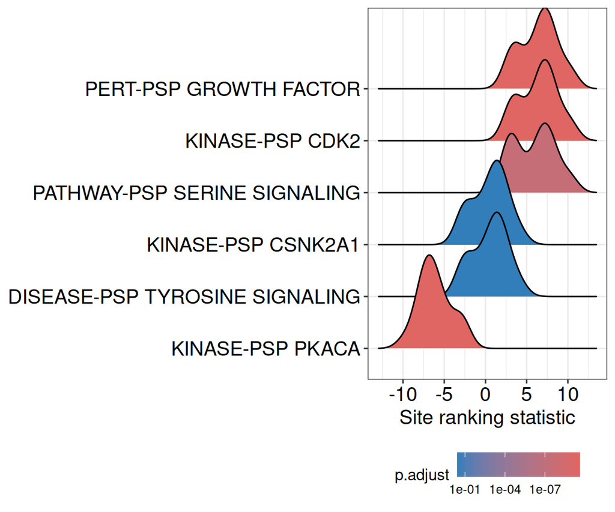

(a) a vs b

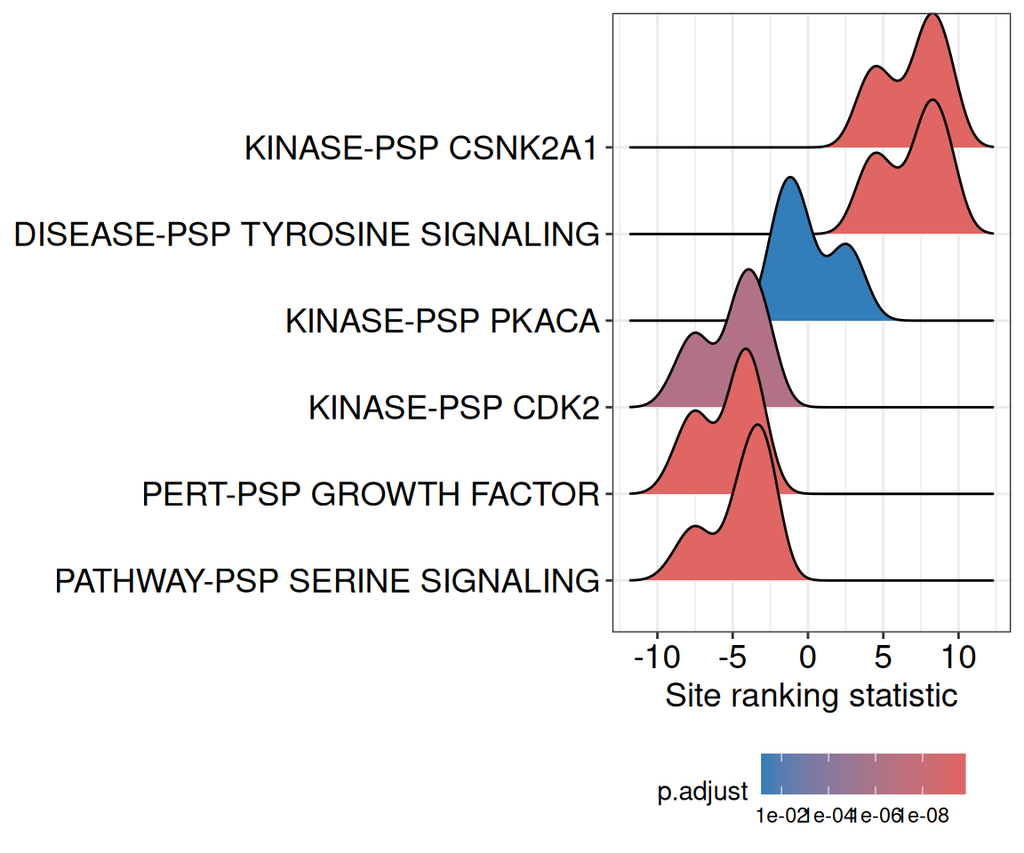

(b) c vs b

Figure 4: DPA PTM-SEA: ranked-site distributions of leading terms, one panel per contrast.

**Gene-set network**

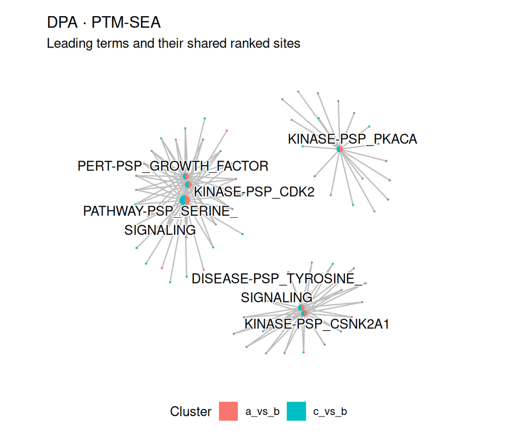

Figure 5: DPA PTM-SEA: leading terms and shared sites.

**Term similarity**

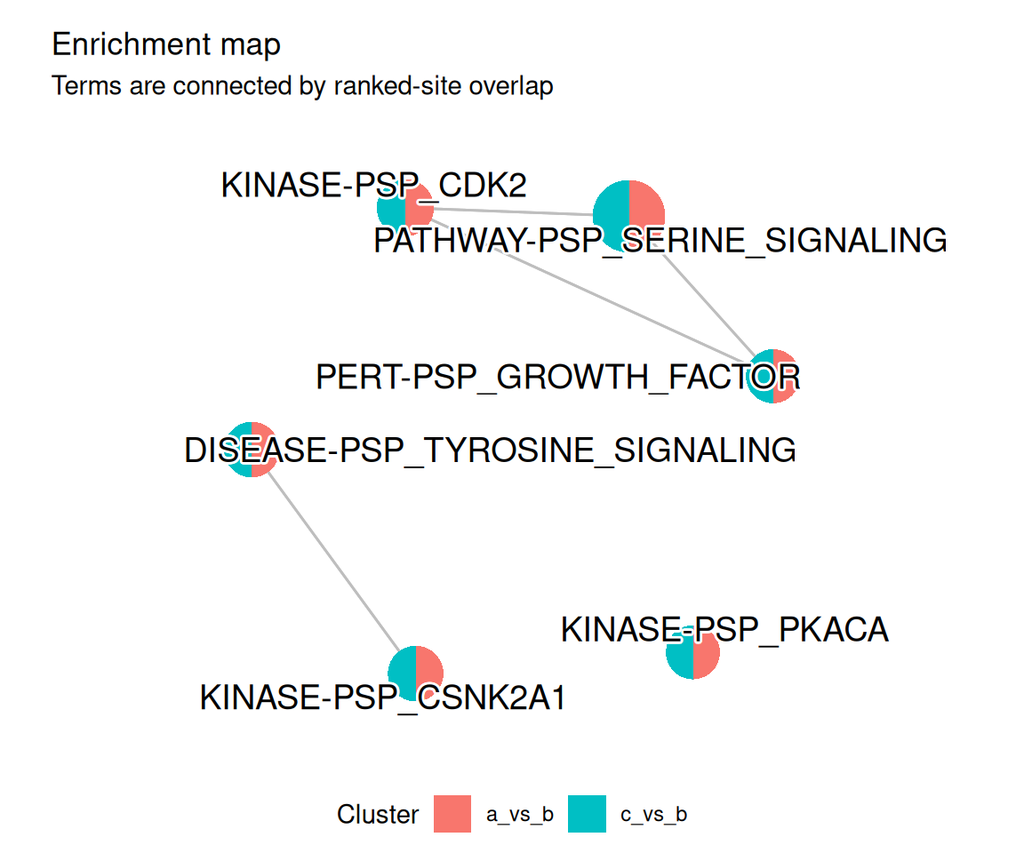

(a) Enrichment map

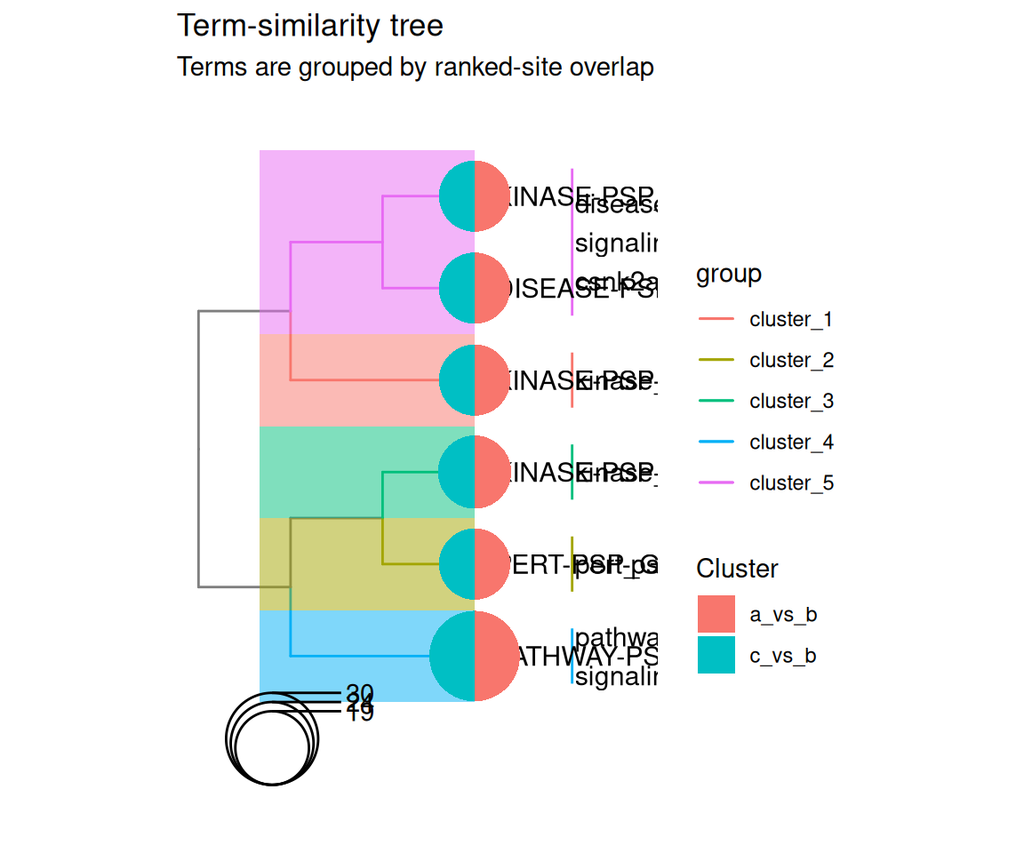

(b) Term-similarity tree

Figure 6: DPA PTM-SEA: term overlap map and similarity tree.

**Results**

Table 3: DPA PTM-SEA: tested-term statistics decoded from MuData JSON; leading-edge site lists remain in JSON.

| Contrast | Term | NES | FDR | Direction | Mapped sites | Set size |
| --- | --- | --- | --- | --- | --- | --- |
| a vs b | KINASE-PSP_PKACA | -2.939 | 2.41e-10 | bottom | 18 | 18 |
| a vs b | PERT-PSP_GROWTH_FACTOR | 2.916 | 2.41e-10 | top | 18 | 18 |
| a vs b | KINASE-PSP_CDK2 | 2.798 | 2.41e-10 | top | 21 | 21 |
| a vs b | PATHWAY-PSP_SERINE_SIGNALING | 2.602 | 3.02e-08 | top | 36 | 36 |
| a vs b | DISEASE-PSP_TYROSINE_SIGNALING | 1.066 | 0.381 | top | 18 | 18 |
| a vs b | KINASE-PSP_CSNK2A1 | 1.066 | 0.381 | top | 18 | 18 |
| c vs b | PATHWAY-PSP_SERINE_SIGNALING | -3.426 | 1.5e-10 | bottom | 36 | 36 |
| c vs b | PERT-PSP_GROWTH_FACTOR | -3.07 | 1.5e-10 | bottom | 18 | 18 |
| c vs b | DISEASE-PSP_TYROSINE_SIGNALING | 2.896 | 1.5e-10 | top | 18 | 18 |
| c vs b | KINASE-PSP_CSNK2A1 | 2.896 | 1.5e-10 | top | 18 | 18 |

[output cut: 2 more lines]

**Kinase GSEA**

**Summary**

Table 4: DPA Kinase GSEA: result counts by contrast and direction.

| Contrast | Tested terms | FDR-significant | Positive NES | Negative NES |
| --- | --- | --- | --- | --- |
| a vs b | 6 | 4 | 3 | 1 |
| c vs b | 6 | 6 | 3 | 3 |

**Dot plot**

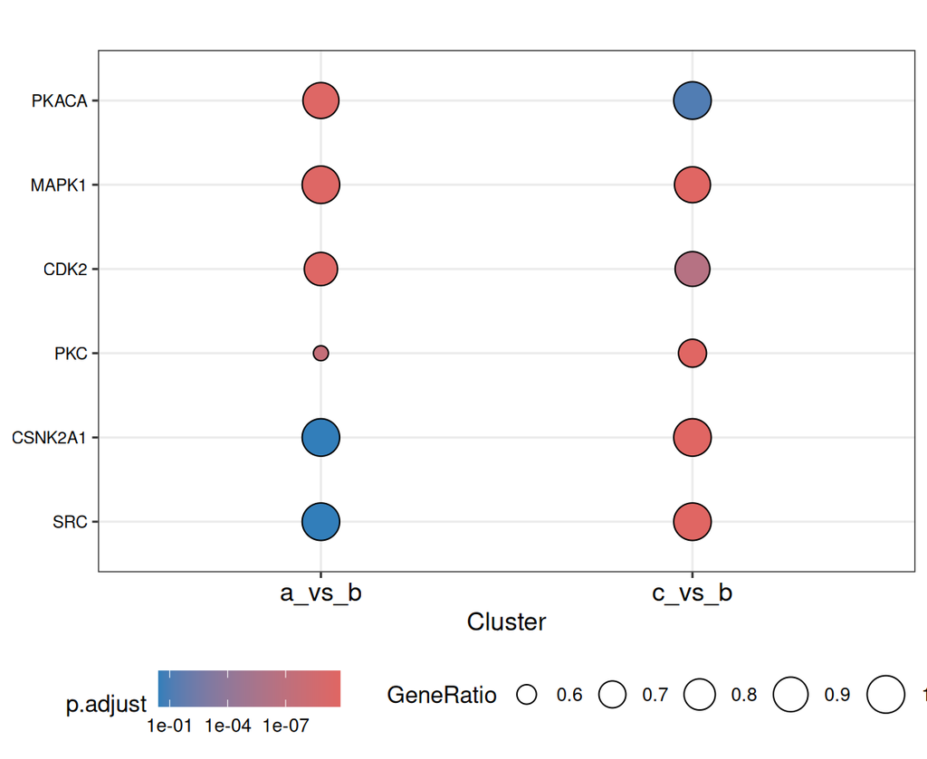

Figure 7: DPA Kinase GSEA: leading enrichment terms reconstructed from JSON.

**Heatmap**

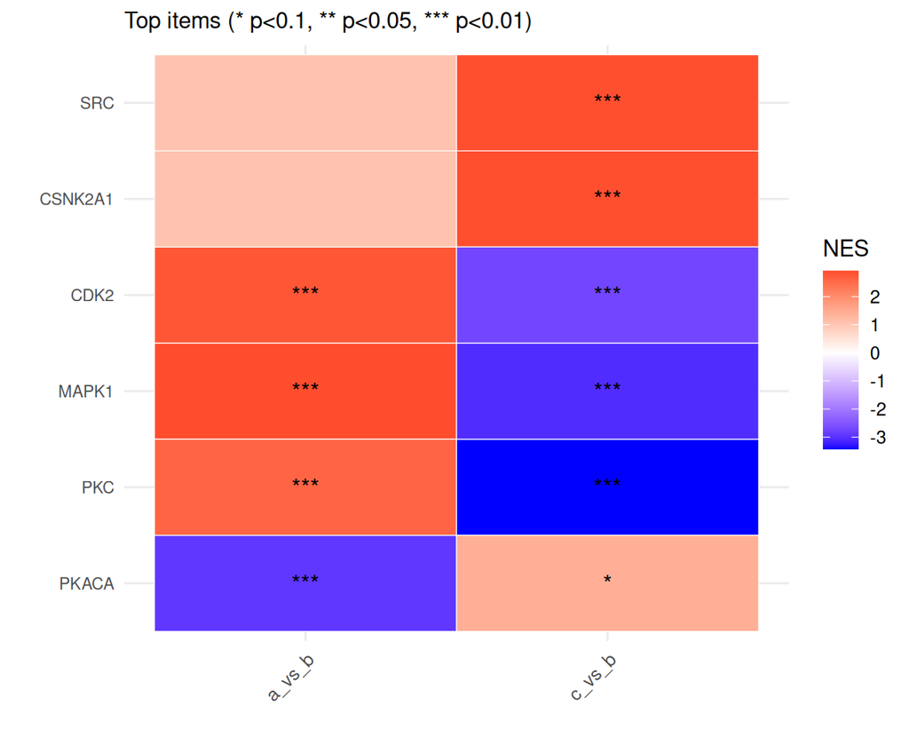

Figure 8: DPA Kinase GSEA: normalized enrichment scores across contrasts.

**Volcano**

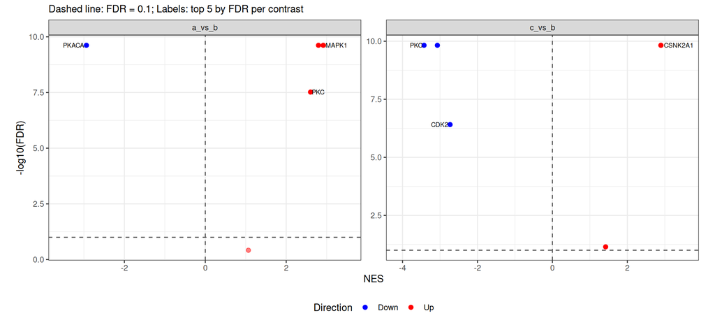

Figure 9: DPA Kinase GSEA: normalized enrichment score versus FDR.

**Rank distributions**

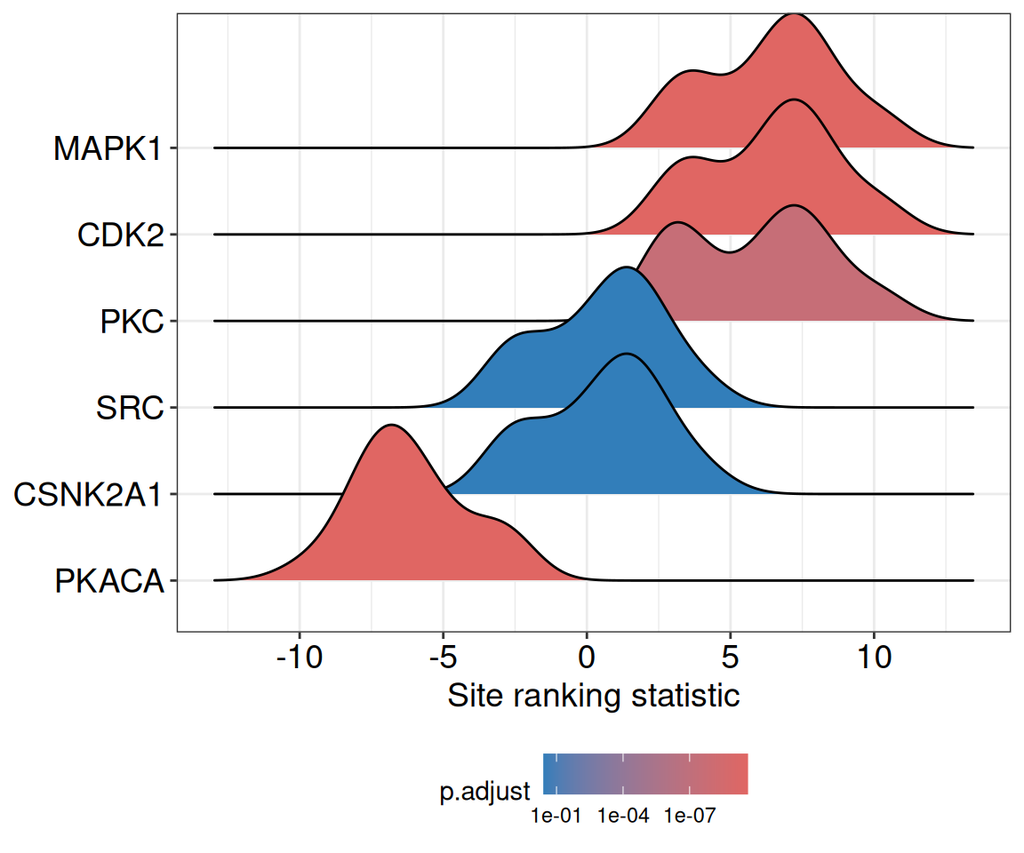

(a) a vs b

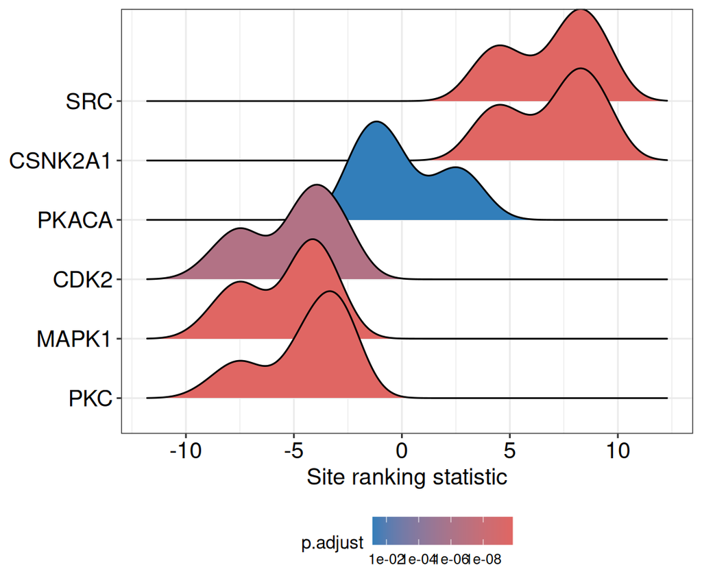

(b) c vs b

Figure 10: DPA Kinase GSEA: ranked-site distributions of leading terms, one panel per contrast.

**Gene-set network**

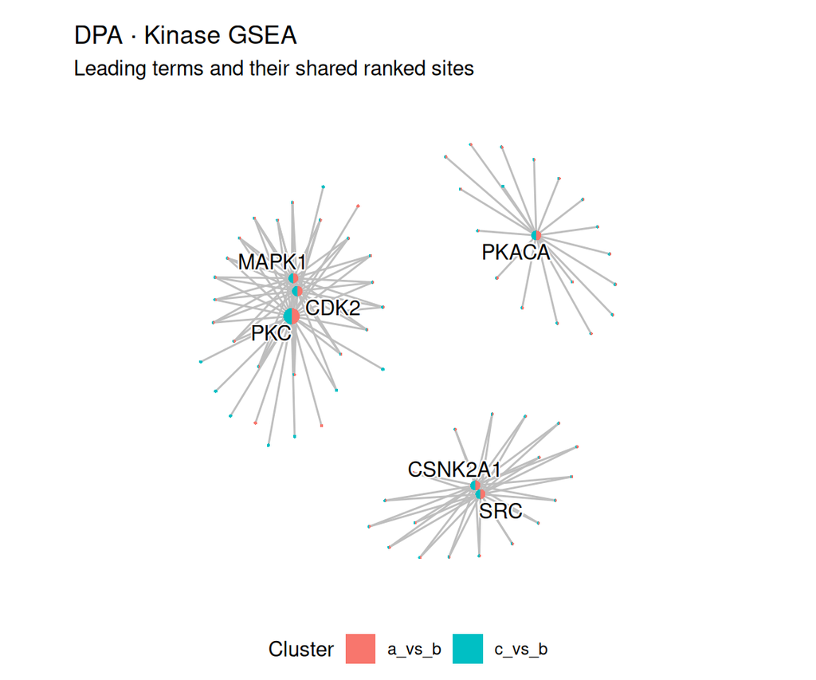

Figure 11: DPA Kinase GSEA: leading terms and shared sites.

**Term similarity**

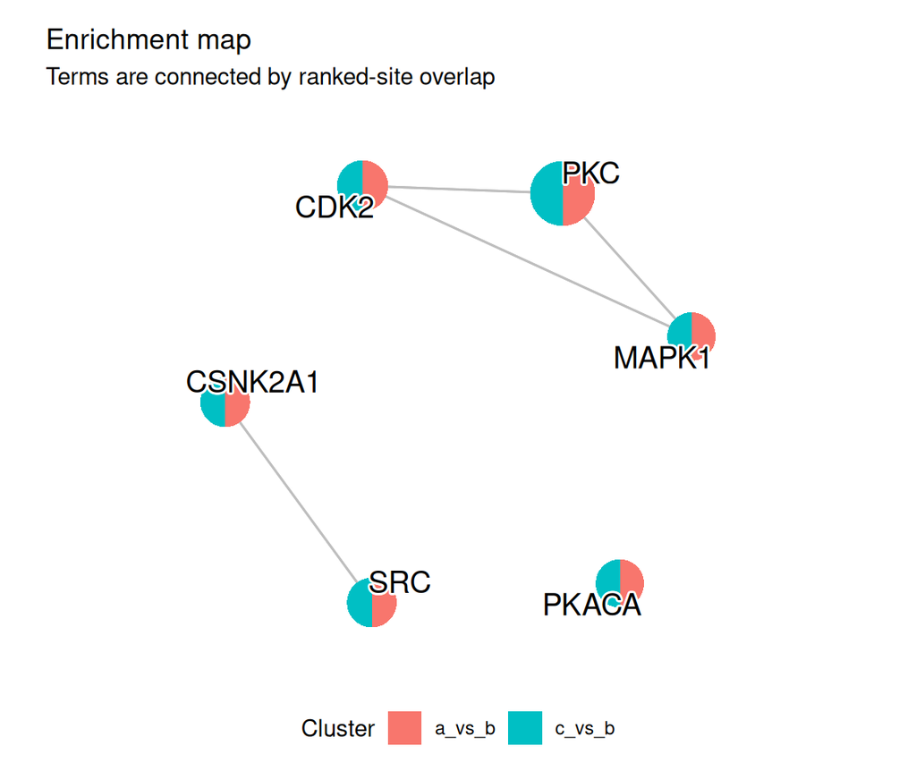

(a) Enrichment map

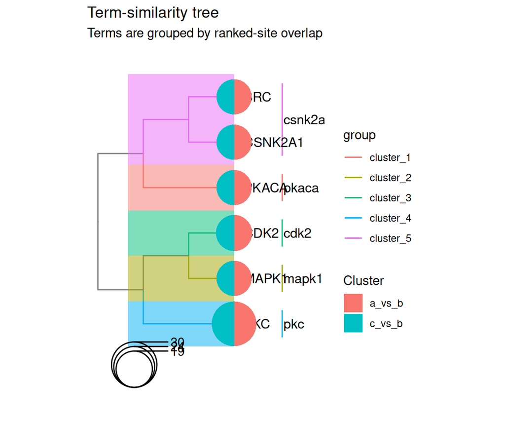

(b) Term-similarity tree

Figure 12: DPA Kinase GSEA: term overlap map and similarity tree.

**Results**

Table 5: DPA Kinase GSEA: tested-term statistics decoded from MuData JSON; leading-edge site lists remain in JSON.

| Contrast | Term | NES | FDR | Direction | Mapped sites | Set size |
| --- | --- | --- | --- | --- | --- | --- |
| a vs b | PKACA | -2.939 | 2.41e-10 | bottom | 18 | 18 |
| a vs b | MAPK1 | 2.916 | 2.41e-10 | top | 18 | 18 |
| a vs b | CDK2 | 2.798 | 2.41e-10 | top | 21 | 21 |
| a vs b | PKC | 2.602 | 3.02e-08 | top | 36 | 36 |
| a vs b | CSNK2A1 | 1.066 | 0.381 | top | 18 | 18 |
| a vs b | SRC | 1.066 | 0.381 | top | 18 | 18 |
| c vs b | PKC | -3.426 | 1.5e-10 | bottom | 36 | 36 |
| c vs b | MAPK1 | -3.07 | 1.5e-10 | bottom | 18 | 18 |
| c vs b | CSNK2A1 | 2.896 | 1.5e-10 | top | 18 | 18 |
| c vs b | SRC | 2.896 | 1.5e-10 | top | 18 | 18 |

[output cut: 2 more lines]

**MEA**

**Summary**

Table 6: DPA MEA: result counts by contrast and direction.

| Contrast | Tested terms | FDR-significant | Positive NES | Negative NES |
| --- | --- | --- | --- | --- |
| a vs b | 6 | 4 | 3 | 1 |
| c vs b | 6 | 6 | 3 | 3 |

**Dot plot**

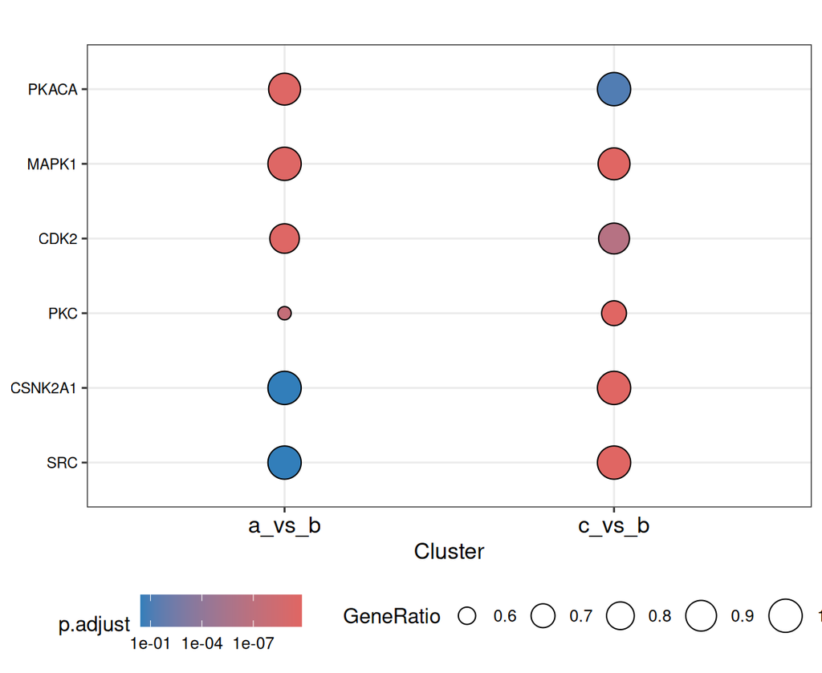

Figure 13: DPA MEA: leading enrichment terms reconstructed from JSON.

**Heatmap**

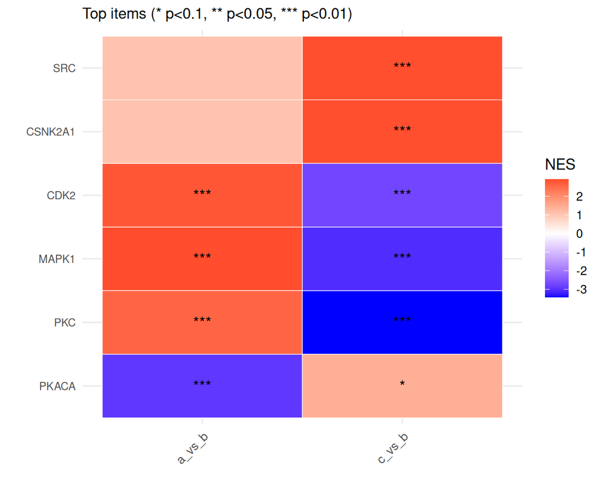

Figure 14: DPA MEA: normalized enrichment scores across contrasts.

**Volcano**

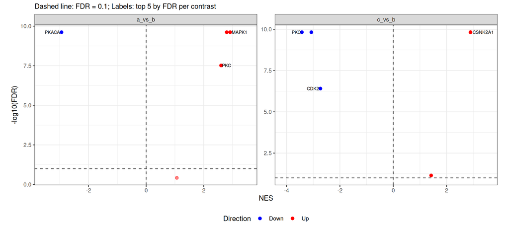

Figure 15: DPA MEA: normalized enrichment score versus FDR.

**Rank distributions**

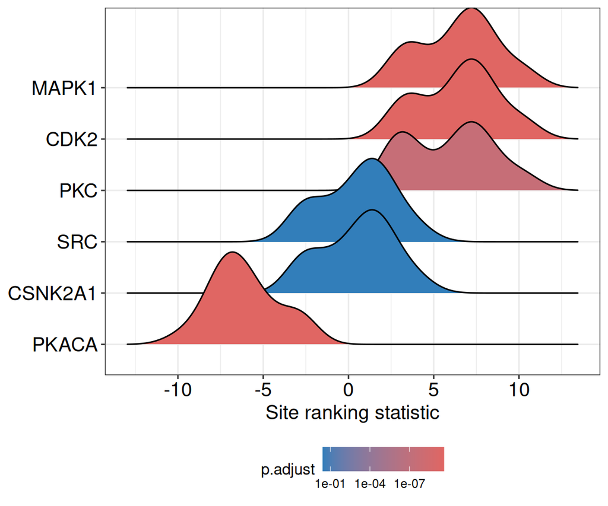

(a) a vs b

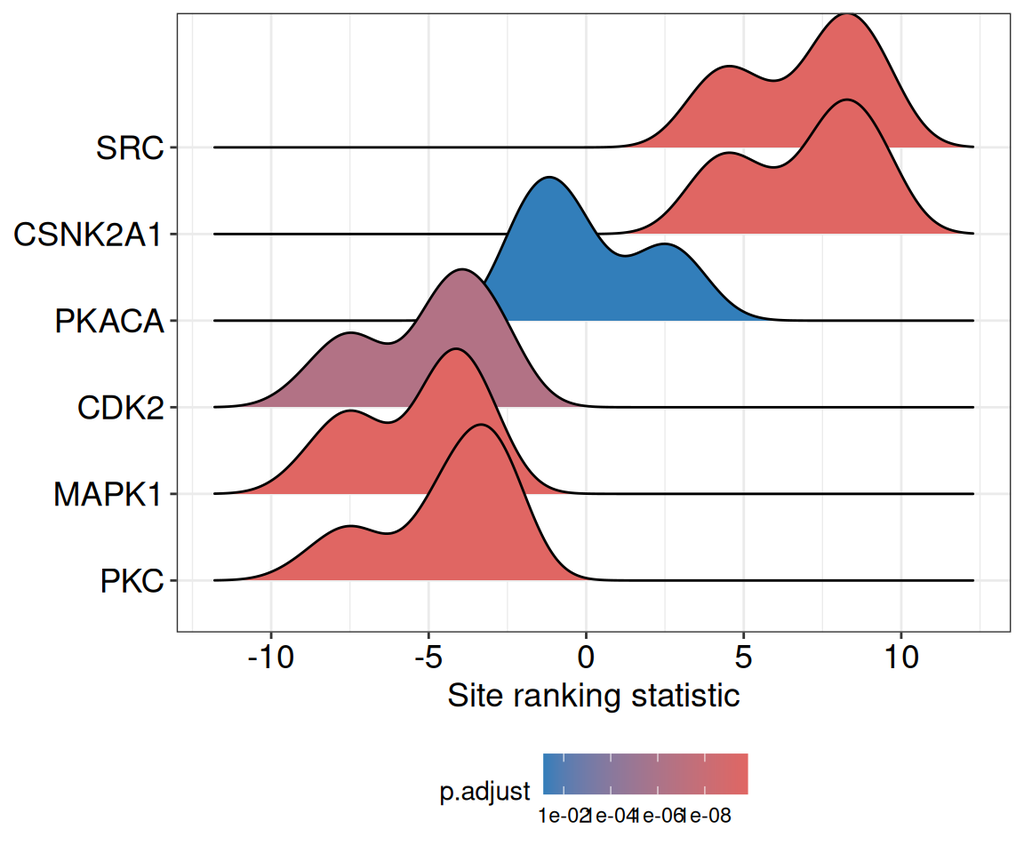

(b) c vs b

Figure 16: DPA MEA: ranked-site distributions of leading terms, one panel per contrast.

**Gene-set network**

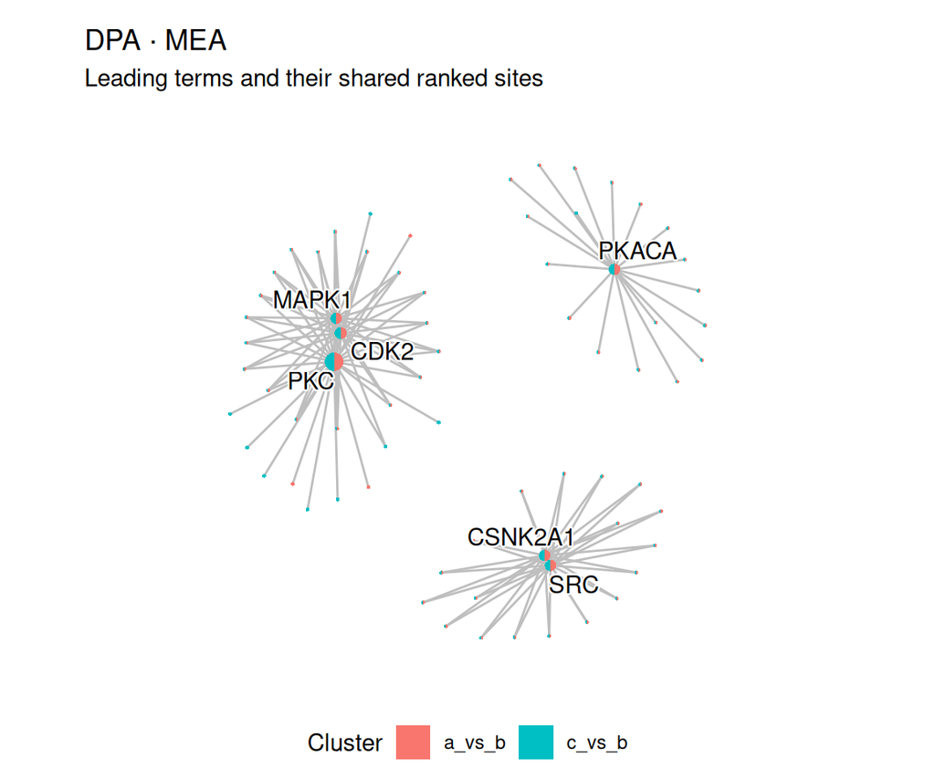

Figure 17: DPA MEA: leading terms and shared sites.

**Term similarity**

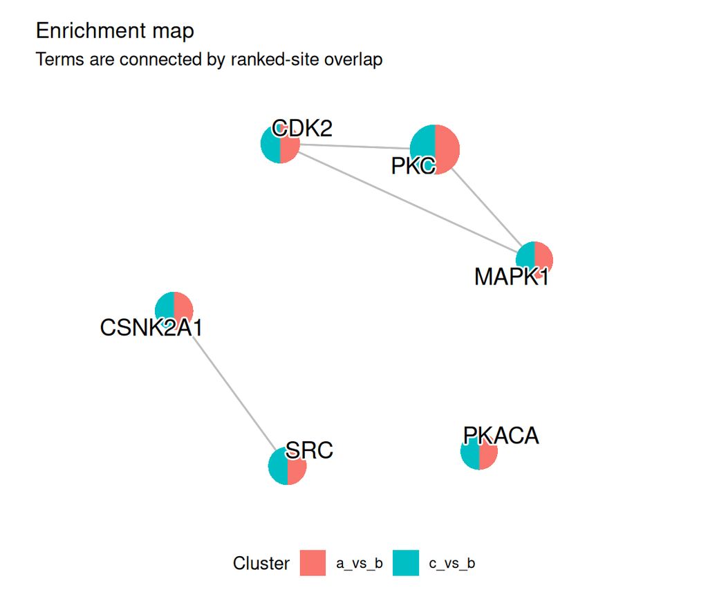

(a) Enrichment map

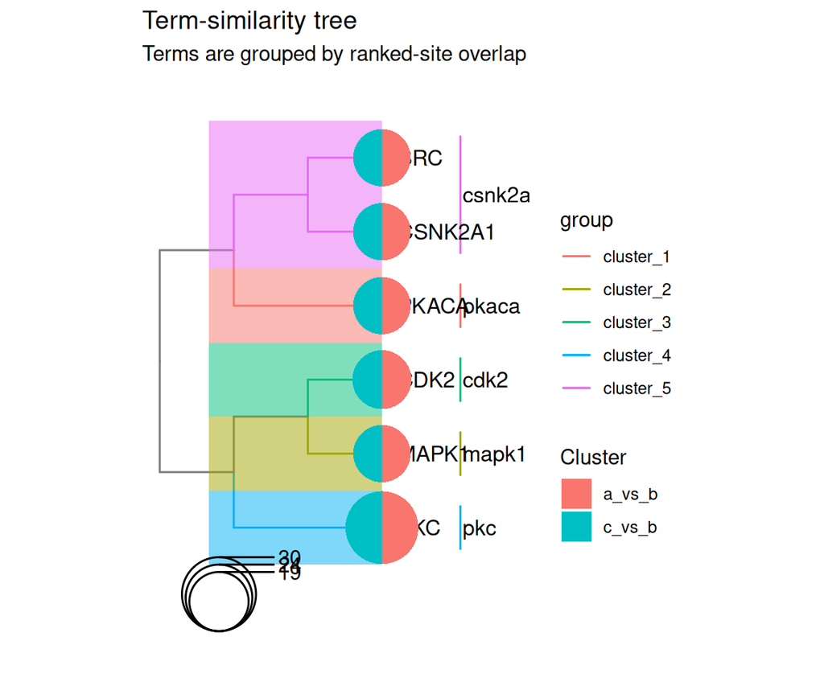

(b) Term-similarity tree

Figure 18: DPA MEA: term overlap map and similarity tree.

**Results**

Table 7: DPA MEA: tested-term statistics decoded from MuData JSON; leading-edge site lists remain in JSON.

| Contrast | Term | NES | FDR | Direction | Mapped sites | Set size |
| --- | --- | --- | --- | --- | --- | --- |
| a vs b | PKACA | -2.939 | 2.41e-10 | bottom | 18 | 18 |
| a vs b | MAPK1 | 2.916 | 2.41e-10 | top | 18 | 18 |
| a vs b | CDK2 | 2.798 | 2.41e-10 | top | 21 | 21 |
| a vs b | PKC | 2.602 | 3.02e-08 | top | 36 | 36 |
| a vs b | CSNK2A1 | 1.066 | 0.381 | top | 18 | 18 |
| a vs b | SRC | 1.066 | 0.381 | top | 18 | 18 |
| c vs b | PKC | -3.426 | 1.5e-10 | bottom | 36 | 36 |
| c vs b | MAPK1 | -3.07 | 1.5e-10 | bottom | 18 | 18 |
| c vs b | CSNK2A1 | 2.896 | 1.5e-10 | top | 18 | 18 |
| c vs b | SRC | 2.896 | 1.5e-10 | top | 18 | 18 |

[output cut: 2 more lines]

**About methods**

## PTM-SEA

PTM-SEA tests curated PTMsigDB phosphosite signatures against the ranked site statistics. Its table retains every tested signature, including those above the report’s FDR threshold.

## Kinase GSEA

Kinase GSEA tests substrate sets assigned by the kinase-library motif scan against the same ranked site statistics. It reports tested kinase sets and their adjusted p-values, including non-significant sets.

## MEA

MEA uses the kinase-library workflow’s GSEApy motif-enrichment calculation. Its scores and adjusted p-values come from that Python computation; this report reads the stored JSON without recomputing them.

**Session Info**

**Report provenance**

Table 8: Report provenance and JSON parameters.

|  | Field | Value |
| --- | --- | --- |
| 1 | Analysis | DPA |
| 2 | Input MuData | /home/runner/work/_temp/Library/prophosqua/extdata/ptm_results_example/PTM_results.h5mu |
| 4 | Method documents | 3 |
| 5 | FDR threshold | 0.1 |
| 6 | Top terms per summary plot | 10 |
| 7 | Report package | prophosqua 0.3.0 |
| 8 | Generated at | 2026-10-21 09:10:12 UTC |
| 9 | QMD source | ptm_enrichment.qmd |

**R session info**

## Download

- Qmd source
- HTML page

Select all plots

Plots download at the resolution embedded in the report (its fig-dpi). Interactive (plotly) charts aren't listed — export those from their own toolbar.